# Master en Big Data. Fundamentos Matemáticos del Análisis de Datos (FMAD).

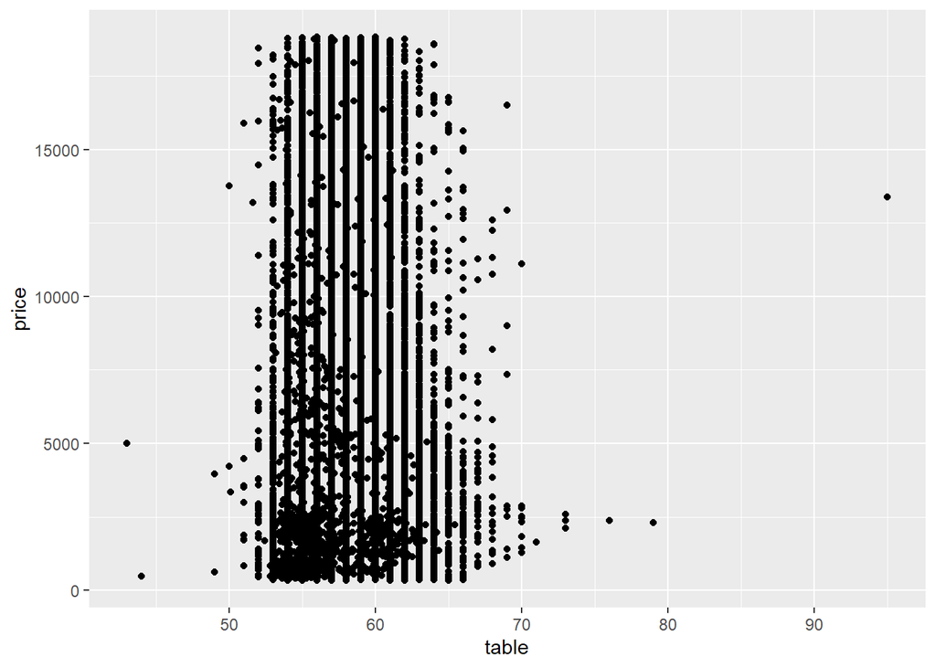

```r
ggplot(data = diamonds, mapping = aes(x = table, y = price)) +
  geom_point()
```

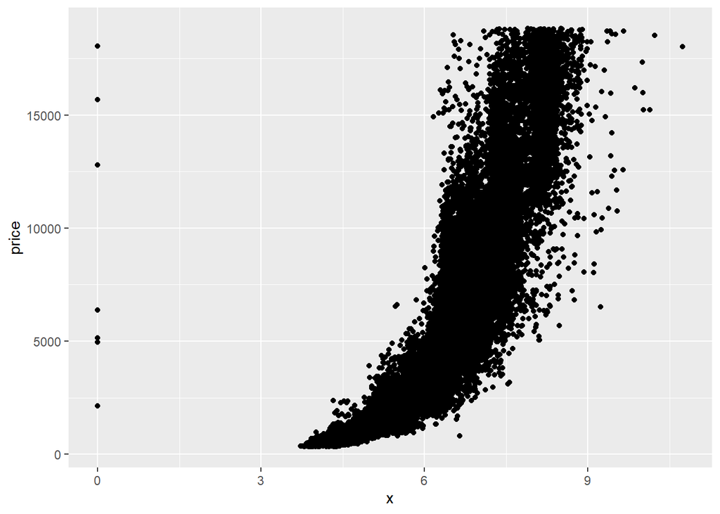

```r
ggplot(data = diamonds, mapping = aes(x = x, y = price)) +
  geom_point()
```

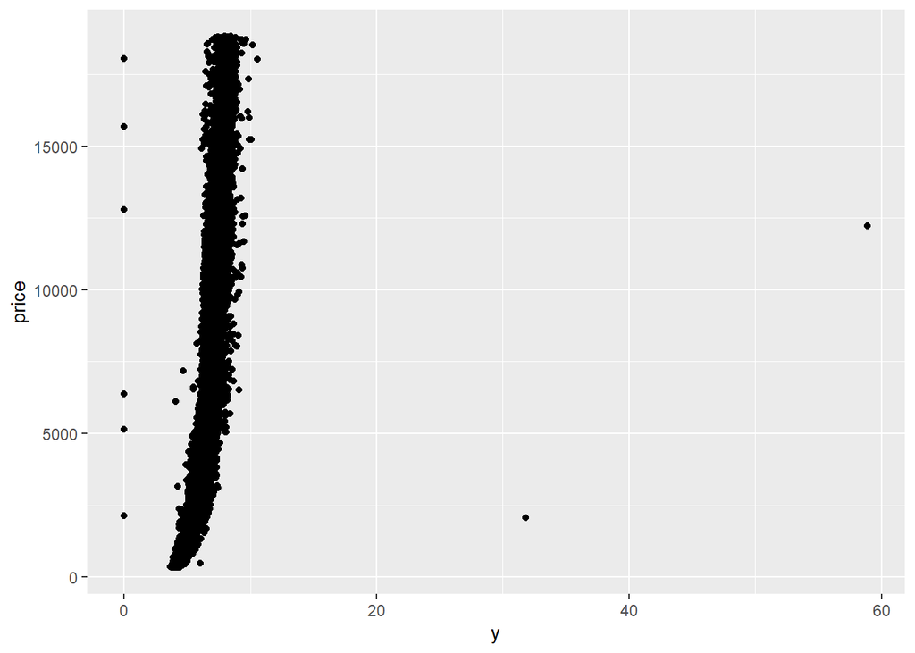

```r
ggplot(data = diamonds, mapping = aes(x = y, y = price)) +
  geom_point()
```

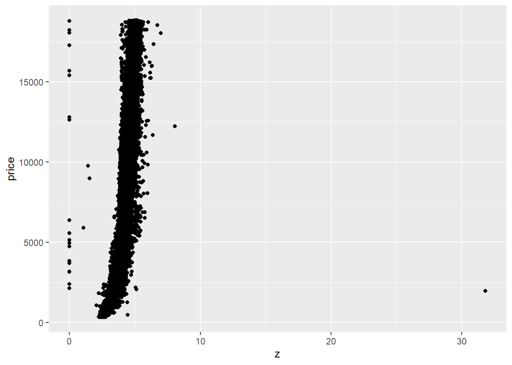

```r
ggplot(data = diamonds, mapping = aes(x = z, y = price)) +
  geom_point()
```

Las variables depth y table no influyen para predecir el precio. Las variables que sí influyen y además de forma parecida son carat (peso/kilates) y las variables x,y,z correspondientes al volumen del diamante. Consideramos que carat es la variable más importante para predecir el precio.

Ahora vemos como carat está correlacionada con cut:

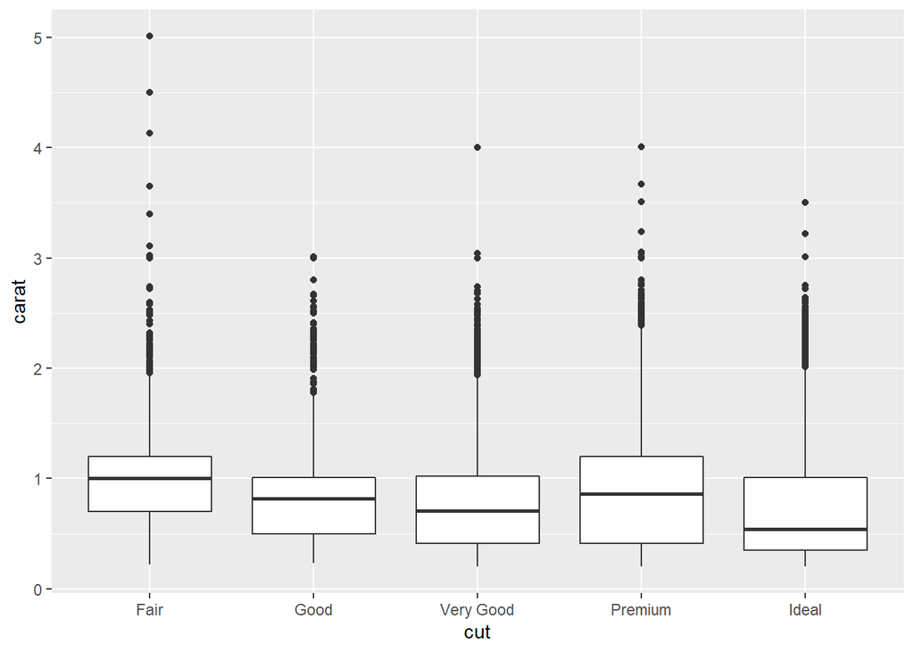

```r
ggplot(data = diamonds, mapping = aes(x = cut, y = carat)) +
  geom_boxplot()
```

Observamos que cuanto mejor es el cut más bajo es el carat. Los diamantes con mejor cut son más pequeños y por tanto más baratos. Por eso ocurre que si miramos únicamente la variable cut para predecir el precio vemos que a mejor cut menor precio.

- Haz el [ejercicio 4 de la Sección 12.6.1 de R4DS](https://r4ds.had.co.nz/tidy-data.html#exercises-27). ¡Aprovecha el código previo de esa sección para trabajar con datos limpios!
- For each country, year, and sex compute the total number of cases of TB. Make an informative visualisation of the data.

**Respuesta:** Usaremos el conjunto de datos who. Con el siguiente fragmento de código obtenido de la sección obtenemos el conjunto de datos limpio (tidy).

```r
whoTidy = who %>%
  pivot_longer(
    cols = new_sp_m014:newrel_f65,
    names_to = "key",
    values_to = "cases",
    values_drop_na = TRUE
  ) %>%
  mutate(
    key = stringr::str_replace(key, "newrel", "new_rel")
  ) %>%
  separate(key, c("new", "var", "sexage")) %>%
  select(-new, -iso2, -iso3) %>%
  separate(sexage, c("sex", "age"), sep = 1)
```

Calculamos los casos totales para cada país y mostramos en diferentes gráficas (una por país) la evolución de los casos a lo largo de los años según el sexo. Mostramos únicamente aquellos países con más de 500000 casos:

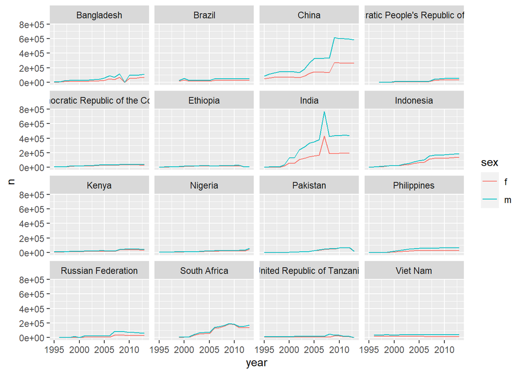

```r
whoTidy %>%
  group_by(country) %>%
  mutate(country_cases = sum(cases)) %>%
  filter(country_cases > 500000) %>%
  group_by(country, year, sex) %>%
  count(wt = cases) %>%
  ggplot(aes(x = year, y = n, colour = sex)) +
  geom_line() +
  facet_wrap(~country)
```